# Informe mensual de las cotizaciones al Sistema de la Protección Social

## 2.6 Evolución de los aportes

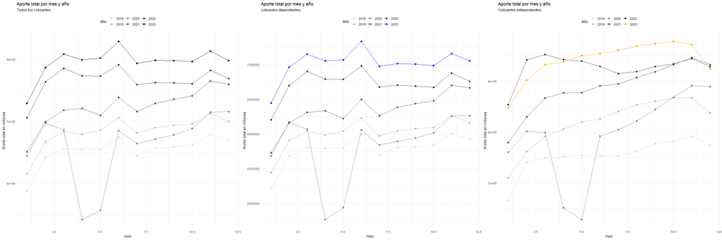

Matriz resumen del monto de cotizacion realizado en DICIEMBRE 2020, 2021, 2022 y 2023, sus variaciones mensuales y anuales por rango y tipo de cotizantes

| Tipo | Rango IBC | Monto en muillones 2020 | Monto en muillones 2021 | Monto en muillones 2022 | Monto en muillones 2023 | Variación mensual 2020 | Variación mensual 2021 | Variación mensual 2022 | Variación mensual 2023 | Variacón anual 2020 | Variacón anual 2021 | Variacón anual 2022 | Variacón anual 2023 |
| --- | --- | --- | --- | --- | --- | --- | --- | --- | --- | --- | --- | --- | --- |
| Dependientes | <1SMMLV | $204.581 | $230.608 | $256.501 | $271.539 | 30.26% | 48.03% | 43.59% | 35.1% | -14.53% | 12.72% | 11.23% | 5.86% |
| Dependientes | 1SMMLV | $559.856 | $575.177 | $594.336 | $626.442 | -14.44% | -9.39% | -10.41% | -17.12% | 2.09% | 2.74% | 3.33% | 5.4% |
| Dependientes | 1_2SMMLV | $1.401.174 | $1.469.083 | $1.483.793 | $1.597.692 | -2.98% | 2.83% | -1.58% | -4.9% | 3.09% | 4.85% | 1% | 7.68% |
| Dependientes | 2_5SMMLV | $1.573.683 | $1.696.034 | $1.711.416 | $1.800.742 | -4.05% | 2.89% | -4.09% | -6.86% | 3.14% | 7.77% | 0.91% | 5.22% |
| Dependientes | >5SMMLV | $2.526.856 | $2.693.292 | $2.712.575 | $2.757.421 | 6.91% | 12.7% | 5.62% | 6.48% | 1.5% | 6.59% | 0.72% | 1.65% |
| Dependientes | Total_IBC | $6.266.150 | $6.664.194 | $6.758.622 | $7.053.837 | 0.11% | 6.5% | 0.84% | -1.48% | 1.69% | 6.35% | 1.42% | 4.37% |
| Independientes | <1SMMLV | $13.419 | $15.659 | $20.480 | $24.706 | 78.66% | 67.66% | 105.61% | 121.21% | -17.59% | 16.69% | 30.79% | 20.64% |
| Independientes | 1SMMLV | $357.950 | $360.102 | $376.954 | $382.477 | 2.02% | -1.18% | 1.76% | -8.96% | 7.32% | 0.6% | 4.68% | 1.46% |
| Independientes | 1_2SMMLV | $174.338 | $185.911 | $171.243 | $174.187 | -6.57% | -3.62% | -18% | -15.2% | 10.1% | 6.64% | -7.89% | 1.72% |
| Independientes | 2_5SMMLV | $167.945 | $176.650 | $160.118 | $161.156 | -2.54% | 1.1% | -13.99% | -5.54% | 5.63% | 5.18% | -9.36% | 0.65% |
| Independientes | >5SMMLV | $175.709 | $193.969 | $199.386 | $182.094 | 17.29% | 29.37% | 16.94% | 10.79% | 3.01% | 10.39% | 2.79% | -8.67% |
| Independientes | Total_IBC | $889.361 | $932.291 | $928.182 | $924.620 | 2.57% | 4.6% | -1.87% | -4.84% | 6.16% | 4.83% | -0.44% | -0.38% |
| Total | Total | $7.155.510 | $7.596.485 | $7.686.804 | $7.978.456 | 0.41% | 6.26% | 0.5% | -1.88% | 2.22% | 6.16% | 1.19% | 3.79% |

Note:  
Se toman en cuenta montos deflactados a partir del valor del IPC con referencia diciembre 2023

# 3 Resultados

- En **Diciembre 2023** se registraron 13.004.954 cotizantes al Sistema de Seguridad Social, *disminuyendo* en un -6.31 % al número de cotizantes en **noviembre 2023** y un decrecimiento anual del -0.98 %. Típicamente se espera que el número de cotizantes en diciembre disminuya en un -2.04 % siendo más bajo al decrecimiento observado, en un escenario sin pandemia se esperan 13.168,7 mil cotizantes, correspondiente al -1.24 % de lo observado.
- El porcentaje de relaciones laborales con novedad de *ingreso* fue de 7.94 %, superior al porcentaje de ingresos el año pasado que fue del 7.31 %, es decir 73.104 cotizantes mas que ingresaron al sistema y corresponde a un aumento anual del 7.62 %. Por su parte, los retiros llegaron a ser del 15.16 % superior a los retiros en el año pasado que fueron del 14.58 %, correspondiente a un crecimiento anual del 2.9 % en esta novedad.
- El número de cotizantes dependientes del sector privado disminuye mensualmente, siendo las actividades económicas de Construcción, Educación y Actividades profesionales, científicas y técnicas las que mas aportan al decrecimiento con un aporte del -0.73 %, -0.53 % y -0.51 % respectivamente. El número de cotizantes en estas actividades tienen variaciones mensuales del -8.3 %, -16.66 % y -3.69 %, en **diciembre** del año pasado las variaciones mensuales en ellas fueron del -6.13 %, -16.55 % y -2.03 %.
- En este periodo, el 54.19 % de los cotizantes son hombres y el 45.81 % son mujeres, correspondiente a 84.53 mujeres por cada 100 hombres cotizando. Este indicador aumentó con relación al 2022 y 2021 que fueron del 83.59 y 82.68. Por su parte el número de cotizantes mujeres presentó una variación anual del -0.33 % inferior al crecimiento anual en 2022 y 2021 que fueron del 4.56 % y 8.4 %; el número de hombres cotizando presentan una disminución anual del -1.45 % hombre reportan igual número de cotizantes entre diciembre de 2023 y 2022, pero en 2022 y 2021 habían presentado incrementos del 3.42 % y 6.38 %.
- En este periodo se registraron 2.931.026 jóvenes (18 a 28 años) cotizando al sistema, y representan el 22.61 % de relaciones laborales, inferior al porcentaje de cotizantes jóvenes en diciembre de 2022 y 2021 que fueron del 23.3 % y 23.14 % respectivamente. El crecimiento anual de cotizantes en esta población es de -3.85 %.

# 4 Aspectos metodológicos

## 4.1 Estimación interanual de las cotizaciones (Año tipo 2012 - 2019)

El **Índice Estacional Medio (IEM)** contrasta el número de relaciones laborales de un mes en particular sobre el total observado en enero de dicho año. La UGPP realiza una estimación del indicador con el fin de conocer el comportamiento típico de los cotizantes a lo largo del año y poder identificar cambios atipicos en los aportes.

## 4.2 Estimación de los cotizantes en cada enero.

El **IEM** está en función del número de cotizantes de cada mes con el número de cotizante en enero de cada año y nos permite conocer el comportamiento esperado interanualmente. Con el fin de tener una estimación en cada periodo, en un escenario sin afectación por pandemia, se realiza una estimación del número de cotizantes en enero de cada año a partir del 2021 a partir del pronóstico de cotizantes como se muestra en la siguiente grafica.

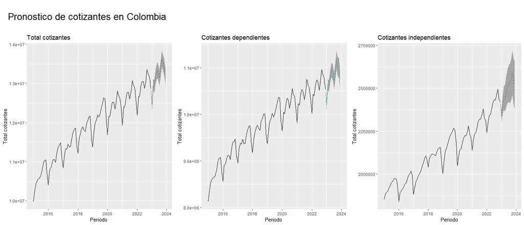

El número esperado de cotizantes en enero 2023, sin la afectación económica, asciende a los 12,4 millones con un crecimiento del 2.2%. El crecimiento anual esperado en los dependientes es del 2.1% y en los independientes del 4.4%.

Total cotizantes estimados de enero en cada año despues de 2021

| Año | Total cotizantes | Var anual (%) | Cot. Dependientes | Var anual (%) | Cot. Dependientes | Var anual (%) |
| --- | --- | --- | --- | --- | --- | --- |
| 2023 | 12.458,6 | 2,2% | 10.219,0 | 2,1% | 2.341,2 | 4,4% |
| 2022 | 12.185,1 | 2,1% | 10.011,4 | 2,0% | 2.241,4 | 4,8% |
| 2021 | 11.930,2 | 2,1% | 9.819,0 | 1,9% | 2.138,6 | 4,3% |
| 2020 | 11.690,3 | 2,8% | 9.640,6 | 2,9% | 2.049,6 | 2,3% |
| 2019 | 11.369,7 | 1,4% | 9.366,2 | 2,1% | 2.003,6 | -1,8% |
| 2018 | 11.216,5 | 0,0% | 9.176,3 | 0,0% | 2.040,2 | 0,0% |